# Global COVID-19 Data Analysis

This project analyzes the COVID-19 dataset across different countries and regions of the world.  
The main objectives are:

- To clean and prepare the dataset for analysis.
- To identify countries/regions with the highest and lowest number of cases.
- To explore patterns and trends using tables and visualizations.

The dataset has been taken from *Kaggle* in the form of *Excel and CSV files*.

#### Import Libraries

```python
import numpy as np
import pandas as pd
import matplotlib.pyplot as plt

from matplotlib import style
style.use('ggplot')

import plotly
import plotly.express as px
import plotly.io as pio
import plotly.graph_objects as go

import seaborn as sns

import folium
```

#### Reading Data

```python
df = pd.read_excel(r"C:\Users\sneha\Downloads\Covid cases in India.xlsx")
```

```python
df
```

|  | S. No. | Name of State / UT | Total Confirmed cases (Indian National) | Total Confirmed cases ( Foreign National ) | Cured | Death |
| --- | --- | --- | --- | --- | --- | --- |
| 0 | 1 | Andhra Pradesh | 12 | 0 | 1 | 0 |
| 1 | 2 | Chhattisgarh | 6 | 0 | 0 | 0 |
| 2 | 3 | Delhi | 38 | 1 | 6 | 1 |
| 3 | 4 | Gujarat | 43 | 0 | 0 | 3 |
| 4 | 5 | Haryana | 16 | 14 | 11 | 0 |
| 5 | 6 | Himachal Pradesh | 4 | 0 | 0 | 1 |
| 6 | 7 | Karnataka | 20 | 0 | 3 | 2 |
| 7 | 8 | Kerala | 131 | 7 | 11 | 0 |
| 8 | 9 | Madhya Pradesh | 23 | 0 | 0 | 1 |
| 9 | 10 | Maharashtra | 144 | 3 | 15 | 4 |
| 10 | 11 | Odisha | 3 | 0 | 0 | 0 |
| 11 | 12 | Puducherry | 1 | 0 | 0 | 0 |
| 12 | 13 | Punjab | 29 | 0 | 0 | 1 |
| 13 | 14 | Rajasthan | 41 | 2 | 3 | 0 |
| 14 | 15 | Tamil Nadu | 32 | 3 | 1 | 1 |
| 15 | 16 | Telengana | 34 | 11 | 1 | 0 |
| 16 | 17 | Chandigarh | 7 | 0 | 0 | 0 |
| 17 | 18 | Jammu and Kashmir | 18 | 0 | 1 | 1 |
| 18 | 19 | Ladakh | 13 | 0 | 0 | 0 |
| 19 | 20 | Uttar Pradesh | 42 | 1 | 11 | 0 |
| 20 | 21 | Uttarakhand | 4 | 0 | 0 | 0 |
| 21 | 22 | West Bengal | 11 | 0 | 0 | 1 |
| 22 | 23 | Bihar | 7 | 0 | 0 | 1 |
| 23 | 24 | Mizoram | 1 | 0 | 0 | 0 |
| 24 | 25 | Goa | 6 | 0 | 0 | 0 |
| 25 | 26 | Manipur | 1 | 0 | 0 | 0 |

#### Drop useless columns

```python
df.drop(['S. No.'],axis=1,inplace=True)
```

```python
df
```

|  | Name of State / UT | Total Confirmed cases (Indian National) | Total Confirmed cases ( Foreign National ) | Cured | Death |
| --- | --- | --- | --- | --- | --- |
| 0 | Andhra Pradesh | 12 | 0 | 1 | 0 |
| 1 | Chhattisgarh | 6 | 0 | 0 | 0 |
| 2 | Delhi | 38 | 1 | 6 | 1 |
| 3 | Gujarat | 43 | 0 | 0 | 3 |
| 4 | Haryana | 16 | 14 | 11 | 0 |
| 5 | Himachal Pradesh | 4 | 0 | 0 | 1 |
| 6 | Karnataka | 20 | 0 | 3 | 2 |
| 7 | Kerala | 131 | 7 | 11 | 0 |
| 8 | Madhya Pradesh | 23 | 0 | 0 | 1 |
| 9 | Maharashtra | 144 | 3 | 15 | 4 |
| 10 | Odisha | 3 | 0 | 0 | 0 |
| 11 | Puducherry | 1 | 0 | 0 | 0 |
| 12 | Punjab | 29 | 0 | 0 | 1 |
| 13 | Rajasthan | 41 | 2 | 3 | 0 |
| 14 | Tamil Nadu | 32 | 3 | 1 | 1 |
| 15 | Telengana | 34 | 11 | 1 | 0 |
| 16 | Chandigarh | 7 | 0 | 0 | 0 |
| 17 | Jammu and Kashmir | 18 | 0 | 1 | 1 |
| 18 | Ladakh | 13 | 0 | 0 | 0 |
| 19 | Uttar Pradesh | 42 | 1 | 11 | 0 |
| 20 | Uttarakhand | 4 | 0 | 0 | 0 |
| 21 | West Bengal | 11 | 0 | 0 | 1 |
| 22 | Bihar | 7 | 0 | 0 | 1 |
| 23 | Mizoram | 1 | 0 | 0 | 0 |
| 24 | Goa | 6 | 0 | 0 | 0 |
| 25 | Manipur | 1 | 0 | 0 | 0 |

```python
#Shape (rows , columns)
df.shape
```

```
(26, 5)
```

#### Adding "Total Cases" Column

```python
df['Total Cases']=df['Total Confirmed cases (Indian National)']+df['Total Confirmed cases ( Foreign National )']
```

```python
df
```

|  | Name of State / UT | Total Confirmed cases (Indian National) | Total Confirmed cases ( Foreign National ) | Cured | Death | Total Cases |
| --- | --- | --- | --- | --- | --- | --- |
| 0 | Andhra Pradesh | 12 | 0 | 1 | 0 | 12 |
| 1 | Chhattisgarh | 6 | 0 | 0 | 0 | 6 |
| 2 | Delhi | 38 | 1 | 6 | 1 | 39 |
| 3 | Gujarat | 43 | 0 | 0 | 3 | 43 |
| 4 | Haryana | 16 | 14 | 11 | 0 | 30 |
| 5 | Himachal Pradesh | 4 | 0 | 0 | 1 | 4 |
| 6 | Karnataka | 20 | 0 | 3 | 2 | 20 |
| 7 | Kerala | 131 | 7 | 11 | 0 | 138 |
| 8 | Madhya Pradesh | 23 | 0 | 0 | 1 | 23 |
| 9 | Maharashtra | 144 | 3 | 15 | 4 | 147 |
| 10 | Odisha | 3 | 0 | 0 | 0 | 3 |
| 11 | Puducherry | 1 | 0 | 0 | 0 | 1 |
| 12 | Punjab | 29 | 0 | 0 | 1 | 29 |
| 13 | Rajasthan | 41 | 2 | 3 | 0 | 43 |
| 14 | Tamil Nadu | 32 | 3 | 1 | 1 | 35 |
| 15 | Telengana | 34 | 11 | 1 | 0 | 45 |
| 16 | Chandigarh | 7 | 0 | 0 | 0 | 7 |
| 17 | Jammu and Kashmir | 18 | 0 | 1 | 1 | 18 |
| 18 | Ladakh | 13 | 0 | 0 | 0 | 13 |
| 19 | Uttar Pradesh | 42 | 1 | 11 | 0 | 43 |
| 20 | Uttarakhand | 4 | 0 | 0 | 0 | 4 |
| 21 | West Bengal | 11 | 0 | 0 | 1 | 11 |
| 22 | Bihar | 7 | 0 | 0 | 1 | 7 |
| 23 | Mizoram | 1 | 0 | 0 | 0 | 1 |
| 24 | Goa | 6 | 0 | 0 | 0 | 6 |
| 25 | Manipur | 1 | 0 | 0 | 0 | 1 |

#### Total Cases Across India

```python
total_cases_overall=df['Total Cases'].sum()
print('The total number of cases till now in India is ',total_cases_overall)
```

```
The total number of cases till now in India is  729
```

#### Adding "Active Cases" Column

```python
df['Active Cases']=df['Total Cases']-(df['Death']+df['Cured'])
```

```python
df
```

|  | Name of State / UT | Total Confirmed cases (Indian National) | Total Confirmed cases ( Foreign National ) | Cured | Death | Total Cases | Active Cases |
| --- | --- | --- | --- | --- | --- | --- | --- |
| 0 | Andhra Pradesh | 12 | 0 | 1 | 0 | 12 | 11 |
| 1 | Chhattisgarh | 6 | 0 | 0 | 0 | 6 | 6 |
| 2 | Delhi | 38 | 1 | 6 | 1 | 39 | 32 |
| 3 | Gujarat | 43 | 0 | 0 | 3 | 43 | 40 |
| 4 | Haryana | 16 | 14 | 11 | 0 | 30 | 19 |
| 5 | Himachal Pradesh | 4 | 0 | 0 | 1 | 4 | 3 |
| 6 | Karnataka | 20 | 0 | 3 | 2 | 20 | 15 |
| 7 | Kerala | 131 | 7 | 11 | 0 | 138 | 127 |
| 8 | Madhya Pradesh | 23 | 0 | 0 | 1 | 23 | 22 |
| 9 | Maharashtra | 144 | 3 | 15 | 4 | 147 | 128 |
| 10 | Odisha | 3 | 0 | 0 | 0 | 3 | 3 |
| 11 | Puducherry | 1 | 0 | 0 | 0 | 1 | 1 |
| 12 | Punjab | 29 | 0 | 0 | 1 | 29 | 28 |
| 13 | Rajasthan | 41 | 2 | 3 | 0 | 43 | 40 |
| 14 | Tamil Nadu | 32 | 3 | 1 | 1 | 35 | 33 |
| 15 | Telengana | 34 | 11 | 1 | 0 | 45 | 44 |
| 16 | Chandigarh | 7 | 0 | 0 | 0 | 7 | 7 |
| 17 | Jammu and Kashmir | 18 | 0 | 1 | 1 | 18 | 16 |
| 18 | Ladakh | 13 | 0 | 0 | 0 | 13 | 13 |
| 19 | Uttar Pradesh | 42 | 1 | 11 | 0 | 43 | 32 |
| 20 | Uttarakhand | 4 | 0 | 0 | 0 | 4 | 4 |
| 21 | West Bengal | 11 | 0 | 0 | 1 | 11 | 10 |
| 22 | Bihar | 7 | 0 | 0 | 1 | 7 | 6 |
| 23 | Mizoram | 1 | 0 | 0 | 0 | 1 | 1 |
| 24 | Goa | 6 | 0 | 0 | 0 | 6 | 6 |
| 25 | Manipur | 1 | 0 | 0 | 0 | 1 | 1 |

```python
#Shape (rows , columns)
df.shape
```

```
(26, 7)
```

#### Basic EDA

```python
#Summary Statistics
df.describe()
```

|  | Total Confirmed cases (Indian National) | Total Confirmed cases ( Foreign National ) | Cured | Death | Total Cases | Active Cases |
| --- | --- | --- | --- | --- | --- | --- |
| count | 26.000000 | 26.000000 | 26.000000 | 26.000000 | 26.000000 | 26.000000 |
| mean | 26.423077 | 1.615385 | 2.461538 | 0.653846 | 28.038462 | 24.923077 |
| std | 35.586709 | 3.589729 | 4.420233 | 1.017539 | 36.971860 | 33.063482 |
| min | 1.000000 | 0.000000 | 0.000000 | 0.000000 | 1.000000 | 1.000000 |
| 25% | 6.000000 | 0.000000 | 0.000000 | 0.000000 | 6.000000 | 6.000000 |
| 50% | 14.500000 | 0.000000 | 0.000000 | 0.000000 | 15.500000 | 14.000000 |
| 75% | 33.500000 | 1.000000 | 2.500000 | 1.000000 | 38.000000 | 32.000000 |
| max | 144.000000 | 14.000000 | 15.000000 | 4.000000 | 147.000000 | 128.000000 |

```python
df.info()
```

```
<class 'pandas.core.frame.DataFrame'>
RangeIndex: 26 entries, 0 to 25
Data columns (total 7 columns):
 #   Column                                      Non-Null Count  Dtype
---  ------                                      --------------  -----
 0   Name of State / UT                          26 non-null     object
 1   Total Confirmed cases (Indian National)     26 non-null     int64
 2   Total Confirmed cases ( Foreign National )  26 non-null     int64
 3   Cured                                       26 non-null     int64
 4   Death                                       26 non-null     int64
 5   Total Cases                                 26 non-null     int64
 6   Active Cases                                26 non-null     int64
dtypes: int64(6), object(1)
memory usage: 1.6+ KB
```

```python
#Check missing values
df.isnull().sum()
```

```
Name of State / UT                            0
Total Confirmed cases (Indian National)       0
Total Confirmed cases ( Foreign National )    0
Cured                                         0
Death                                         0
Total Cases                                   0
Active Cases                                  0
dtype: int64
```

```python
dp_val = df.duplicated().any()
print(dp_val)
```

```
False
```

#### Adding Background Colouring to Dataframe

```python
df.style.background_gradient(cmap='Reds')
```

|  | Name of State / UT | Total Confirmed cases (Indian National) | Total Confirmed cases ( Foreign National ) | Cured | Death | Total Cases | Active Cases |
| --- | --- | --- | --- | --- | --- | --- | --- |
| 0 | Andhra Pradesh | 12 | 0 | 1 | 0 | 12 | 11 |
| 1 | Chhattisgarh | 6 | 0 | 0 | 0 | 6 | 6 |
| 2 | Delhi | 38 | 1 | 6 | 1 | 39 | 32 |
| 3 | Gujarat | 43 | 0 | 0 | 3 | 43 | 40 |
| 4 | Haryana | 16 | 14 | 11 | 0 | 30 | 19 |
| 5 | Himachal Pradesh | 4 | 0 | 0 | 1 | 4 | 3 |
| 6 | Karnataka | 20 | 0 | 3 | 2 | 20 | 15 |
| 7 | Kerala | 131 | 7 | 11 | 0 | 138 | 127 |
| 8 | Madhya Pradesh | 23 | 0 | 0 | 1 | 23 | 22 |
| 9 | Maharashtra | 144 | 3 | 15 | 4 | 147 | 128 |
| 10 | Odisha | 3 | 0 | 0 | 0 | 3 | 3 |
| 11 | Puducherry | 1 | 0 | 0 | 0 | 1 | 1 |
| 12 | Punjab | 29 | 0 | 0 | 1 | 29 | 28 |
| 13 | Rajasthan | 41 | 2 | 3 | 0 | 43 | 40 |
| 14 | Tamil Nadu | 32 | 3 | 1 | 1 | 35 | 33 |
| 15 | Telengana | 34 | 11 | 1 | 0 | 45 | 44 |
| 16 | Chandigarh | 7 | 0 | 0 | 0 | 7 | 7 |
| 17 | Jammu and Kashmir | 18 | 0 | 1 | 1 | 18 | 16 |
| 18 | Ladakh | 13 | 0 | 0 | 0 | 13 | 13 |
| 19 | Uttar Pradesh | 42 | 1 | 11 | 0 | 43 | 32 |
| 20 | Uttarakhand | 4 | 0 | 0 | 0 | 4 | 4 |
| 21 | West Bengal | 11 | 0 | 0 | 1 | 11 | 10 |
| 22 | Bihar | 7 | 0 | 0 | 1 | 7 | 6 |
| 23 | Mizoram | 1 | 0 | 0 | 0 | 1 | 1 |
| 24 | Goa | 6 | 0 | 0 | 0 | 6 | 6 |
| 25 | Manipur | 1 | 0 | 0 | 0 | 1 | 1 |

*Maharashtra and Kerala are the hotspots with the highest number of total and active cases.*

*Delhi, Gujarat, Tamil Nadu, and Telangana are in the second tier of concern.*

*Several states/UTs like Odisha, Puducherry, and Himachal Pradesh show very low case counts.*

*Recoveries are happening, but active cases still dominate, meaning containment and treatment are critical. But Maharashtra, Kerala, Haryana, Uttar Pradesh show relatively better recovery.*

*Death counts are still relatively low but Maharashtra has highest death counts(4)*

#### State Wise Active Cases with Background colours

```python
Total_Active_Cases=df.groupby('Name of State / UT')['Active Cases'].sum().sort_values(ascending=False).to_frame()
Total_Active_Cases.style.background_gradient(cmap='Reds')
```

| Name of State / UT | Active Cases |
| --- | --- |
| Maharashtra | 128 |
| Kerala | 127 |
| Telengana | 44 |
| Rajasthan | 40 |
| Gujarat | 40 |
| Tamil Nadu | 33 |
| Uttar Pradesh | 32 |
| Delhi | 32 |
| Punjab | 28 |
| Madhya Pradesh | 22 |
| Haryana | 19 |
| Jammu and Kashmir | 16 |
| Karnataka | 15 |
| Ladakh | 13 |
| Andhra Pradesh | 11 |
| West Bengal | 10 |
| Chandigarh | 7 |
| Bihar | 6 |
| Chhattisgarh | 6 |
| Goa | 6 |
| Uttarakhand | 4 |
| Himachal Pradesh | 3 |
| Odisha | 3 |
| Manipur | 1 |
| Mizoram | 1 |
| Puducherry | 1 |

**1. Worst-hit States**

*Maharashtra (128 cases) and Kerala (127 cases) are the two states with the highest active cases.*

**2. Moderately Affected States**

*Telangana (44), Rajasthan (40), Gujarat (40), Tamil Nadu (33), Uttar Pradesh (32), and Delhi (32) show medium-level active cases.*

**3. Low to Mild Impact States**

*States like Punjab (28), Madhya Pradesh (22), Haryana (19), Jammu & Kashmir (16), and Karnataka (15) are in the next tier, with fewer but still notable cases.*

**4. Least Affected States/UTs**

*Mizoram, Manipur, Puducherry, Odisha, Himachal Pradesh, and Uttarakhand report very few active cases (1–4 each).*

**5. Geographical Pattern**

*Western & Southern India (Maharashtra, Kerala, Tamil Nadu, Gujarat, Telangana, Delhi, UP) are more affected compared to some Northeastern and smaller UTs.*

### Graphical Representation

#### States/UT vs Total Cases

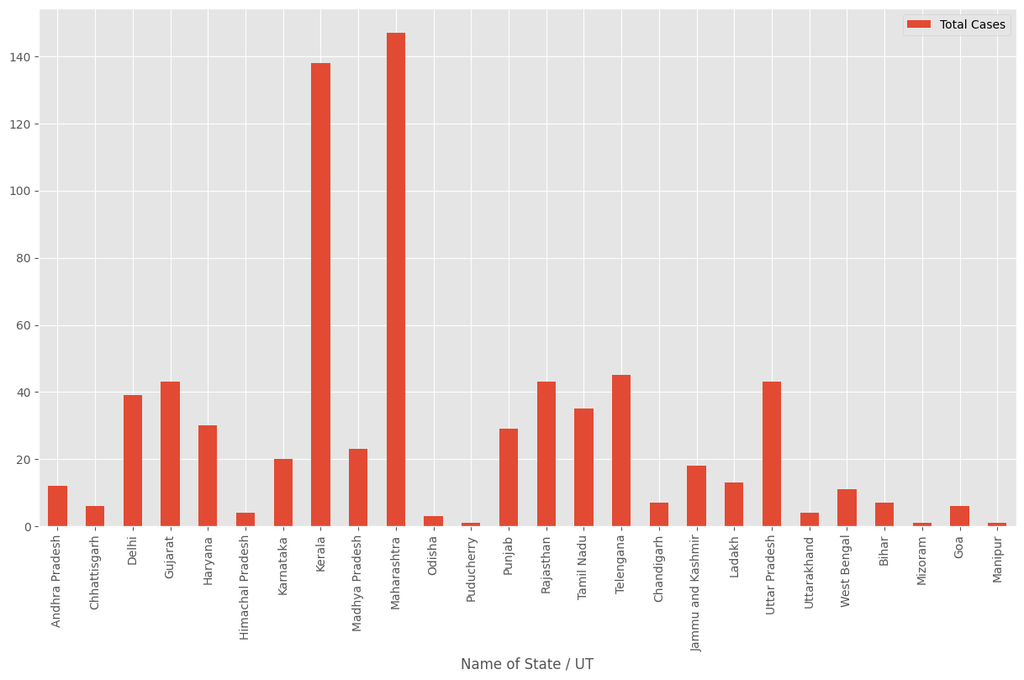

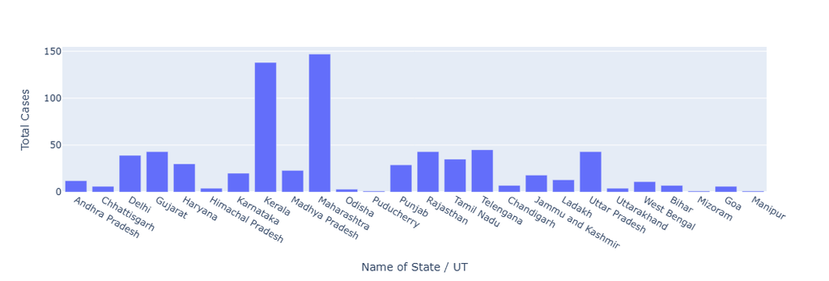

```python
#Using Panda
df.plot(kind='bar',x='Name of State / UT',y='Total Cases', figsize=(15,8))
plt.show()

#Using plotly
fig = px.bar(df, x='Name of State / UT', y='Total Cases')
fig.show()
```

**Comparison of Both Visualizations**

*Matplotlib (Upper) → Best for static reports & printed assignments.*

*Plotly (Lower) → Best for interactive dashboards & presentations.*

**Summary**

*Maharashtra and Kerala stand out with highest total cases, far above others.*

*Medium-level states: Telangana, Rajasthan, Tamil Nadu, Gujarat, Delhi, Uttar Pradesh.*

#### States/UT vs Active Cases

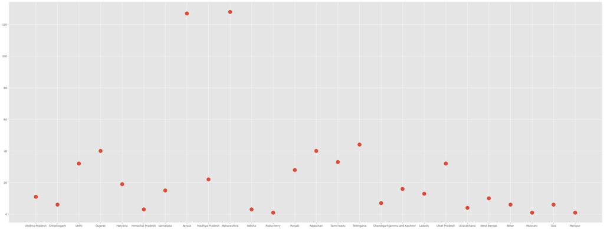

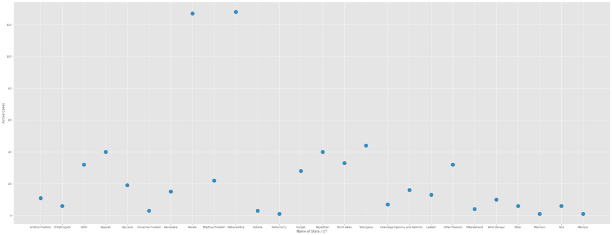

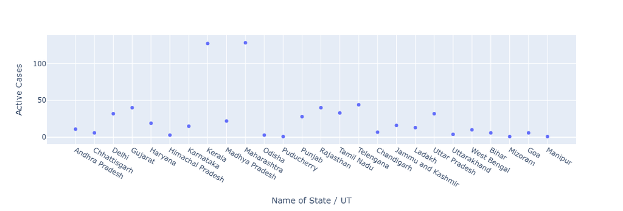

```python
#Using Matplotlib
plt.figure(figsize=(40,15))
plt.scatter(df['Name of State / UT'],df['Active Cases'], s=200)
plt.show()

#Using Pandas
df.plot(kind='scatter',x='Name of State / UT',y='Active Cases', figsize=(40,15), s=200)
plt.show()

#Using PlotlyExpress
px.scatter(df, x='Name of State / UT', y='Active Cases')
```

**Summary**

*Peaks are visible (e.g., Maharashtra(128) , Kerala(127)).*

*Telangana (44), Gujarat (40), Rajasthan (40), Tamil Nadu(33), Delhi(32), Uttar Pradesh(32).*

#### Heatmap

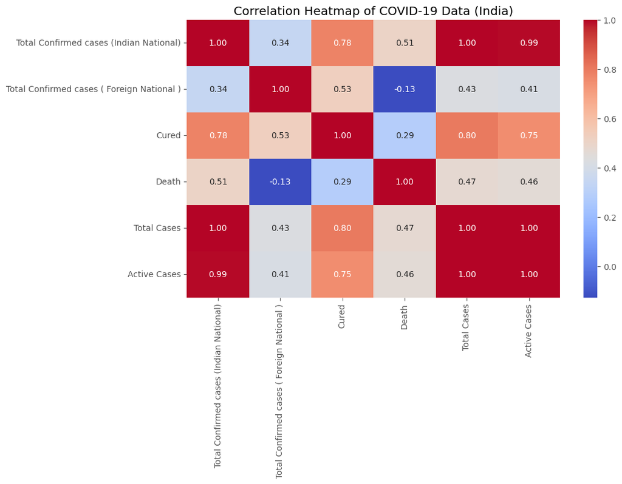

```python
# Select only numerical columns for correlation
numeric_cols = [
    'Total Confirmed cases (Indian National)',
    'Total Confirmed cases ( Foreign National )',
    'Cured',
    'Death',
    'Total Cases',
    'Active Cases'
]

plt.figure(figsize=(10,6))
sns.heatmap(df[numeric_cols].corr(), annot=True, cmap="coolwarm", fmt=".2f")
plt.title("Correlation Heatmap of COVID-19 Data (India)")
plt.show()
```

**Insights from Heatmap**

*Total Cases, Active Cases, and Indian National confirmed cases are highly correlated, showing that Indian National cases are the main contributor to totals.*

*Cured cases have a strong positive correlation with Total Cases, indicating that higher cases also lead to higher recoveries.*

*Deaths show only a moderate correlation with Total Cases, meaning fatalities rise with cases but not as strongly as recoveries.*

*Foreign National cases have weak correlation with other variables, suggesting a minimal impact on overall trends.*

#### Geographical Distribution of Total Cases

```python
Indian_Coordinates = pd.read_excel(r"C:\Users\sneha\Downloads\Indian Coordinates.xlsx")
```

```python
Indian_Coordinates
```

|  | Name of State / UT | Latitude | Longitude |
| --- | --- | --- | --- |
| 0 | Andaman And Nicobar | 11.667026 | 92.735983 |
| 1 | Andhra Pradesh | 14.750429 | 78.570026 |
| 2 | Arunachal Pradesh | 27.100399 | 93.616601 |
| 3 | Assam | 26.749981 | 94.216667 |
| 4 | Bihar | 25.785414 | 87.479973 |
| 5 | Chandigarh | 30.719997 | 76.780006 |
| 6 | Chhattisgarh | 22.090420 | 82.159987 |
| 7 | Dadra And Nagar Haveli | 20.266578 | 73.016618 |
| 8 | Delhi | 28.669993 | 77.230004 |
| 9 | Goa | 15.491997 | 73.818001 |
| 10 | Haryana | 28.450006 | 77.019991 |
| 11 | Himachal Pradesh | 31.100025 | 77.166597 |
| 12 | Union Territory of Jammu and Kashmir | 33.450000 | 76.240000 |
| 13 | Jharkhand | 23.800393 | 86.419986 |
| 14 | Karnataka | 12.570381 | 76.919997 |
| 15 | Kerala | 8.900373 | 76.569993 |
| 16 | Lakshadweep | 10.562573 | 72.636867 |
| 17 | Madhya Pradesh | 21.300391 | 76.130019 |
| 18 | Maharashtra | 19.250232 | 73.160175 |
| 19 | Manipur | 24.799971 | 93.950017 |
| 20 | Meghalaya | 25.570492 | 91.880014 |
| 21 | Mizoram | 23.710399 | 92.720015 |
| 22 | Nagaland | 25.666998 | 94.116570 |
| 23 | Orissa | 19.820430 | 85.900017 |
| 24 | Puducherry | 11.934994 | 79.830000 |
| 25 | Punjab | 31.519974 | 75.980003 |
| 26 | Rajasthan | 26.449999 | 74.639981 |
| 27 | Sikkim | 27.333330 | 88.616647 |
| 28 | Telengana | 18.112400 | 79.019300 |
| 29 | Tamil Nadu | 12.920386 | 79.150042 |
| 30 | Tripura | 23.835404 | 91.279999 |
| 31 | Uttar Pradesh | 27.599981 | 78.050006 |
| 32 | Uttarakhand | 30.320409 | 78.050006 |
| 33 | West Bengal | 22.580390 | 88.329947 |
| 34 | Union Territory of Ladakh | 34.100000 | 77.340000 |

```python
df_complete = pd.merge(Indian_Coordinates,df,on='Name of State / UT')
```

```python
df_complete
```

|  | Name of State / UT | Latitude | Longitude | Total Confirmed cases (Indian National) | Total Confirmed cases ( Foreign National ) | Cured | Death | Total Cases | Active Cases |
| --- | --- | --- | --- | --- | --- | --- | --- | --- | --- |
| 0 | Andhra Pradesh | 14.750429 | 78.570026 | 12 | 0 | 1 | 0 | 12 | 11 |
| 1 | Delhi | 28.669993 | 77.230004 | 38 | 1 | 6 | 1 | 39 | 32 |
| 2 | Haryana | 28.450006 | 77.019991 | 16 | 14 | 11 | 0 | 30 | 19 |
| 3 | Karnataka | 12.570381 | 76.919997 | 20 | 0 | 3 | 2 | 20 | 15 |
| 4 | Kerala | 8.900373 | 76.569993 | 131 | 7 | 11 | 0 | 138 | 127 |
| 5 | Maharashtra | 19.250232 | 73.160175 | 144 | 3 | 15 | 4 | 147 | 128 |
| 6 | Punjab | 31.519974 | 75.980003 | 29 | 0 | 0 | 1 | 29 | 28 |
| 7 | Rajasthan | 26.449999 | 74.639981 | 41 | 2 | 3 | 0 | 43 | 40 |
| 8 | Telengana | 18.112400 | 79.019300 | 34 | 11 | 1 | 0 | 45 | 44 |
| 9 | Tamil Nadu | 12.920386 | 79.150042 | 32 | 3 | 1 | 1 | 35 | 33 |
| 10 | Uttar Pradesh | 27.599981 | 78.050006 | 42 | 1 | 11 | 0 | 43 | 32 |
| 11 | Uttarakhand | 30.320409 | 78.050006 | 4 | 0 | 0 | 0 | 4 | 4 |

#### Bubble Map

```python
map=folium.Map(location=[20,70],zoom_start=4,tiles="OpenStreetMap")

for lat,long,value, name in zip(df_complete['Latitude'],df_complete['Longitude'],df_complete['Total Cases'],df_complete['Name of State / UT']):
    folium.CircleMarker([lat,long],radius = value*0.8,popup=('<strong>State</strong>: '+str(name).capitalize()+'<br>''<strong>Total Cases</strong>: ' + str(value)+ '<br>'),color='red',fill_color='red',fill_opacity=0.3).add_to(map)

map
```

[interactive chart not shown]

**1. Concentration of Cases in Major States/UTs**

**4. Northern Cluster**

*Delhi and surrounding states (Uttar Pradesh, Rajasthan, Haryana) form a dense cluster of red circles, highlighting significant spread in the North.*

**5.Eastern India**

*West Bengal, Odisha, Northeast shows much smaller or no visible circles, suggesting comparatively lower case numbers.*

#### How Corona virus is rising globally

```python
dbd_global= pd.read_csv(r"C:\Users\sneha\Downloads\covid_19_data.csv",parse_dates=True)
```

```python
dbd_global
```

|  | SNo | ObservationDate | Province/State | Country/Region | Last Update | Confirmed | Deaths | Recovered |
| --- | --- | --- | --- | --- | --- | --- | --- | --- |
| 0 | 1 | 01/22/2020 | Anhui | Mainland China | 1/22/2020 17:00 | 1.0 | 0.0 | 0.0 |
| 1 | 2 | 01/22/2020 | Beijing | Mainland China | 1/22/2020 17:00 | 14.0 | 0.0 | 0.0 |
| 2 | 3 | 01/22/2020 | Chongqing | Mainland China | 1/22/2020 17:00 | 6.0 | 0.0 | 0.0 |
| 3 | 4 | 01/22/2020 | Fujian | Mainland China | 1/22/2020 17:00 | 1.0 | 0.0 | 0.0 |
| 4 | 5 | 01/22/2020 | Gansu | Mainland China | 1/22/2020 17:00 | 0.0 | 0.0 | 0.0 |
| ... | ... | ... | ... | ... | ... | ... | ... | ... |
| 5885 | 5886 | 03/15/2020 | Gibraltar | UK | 2020-03-14T16:33:03 | 1.0 | 0.0 | 1.0 |
| 5886 | 5887 | 03/15/2020 | NaN | Uzbekistan | 2020-03-15T18:20:19 | 1.0 | 0.0 | 0.0 |
| 5887 | 5888 | 03/15/2020 | Diamond Princess cruise ship | Australia | 2020-03-14T02:33:04 | 0.0 | 0.0 | 0.0 |
| 5888 | 5889 | 03/15/2020 | West Virginia | US | 2020-03-10T02:33:04 | 0.0 | 0.0 | 0.0 |
| 5889 | 5890 | 03/15/2020 | NaN | occupied Palestinian territory | 2020-03-11T20:53:02 | 0.0 | 0.0 | 0.0 |

5890 rows × 8 columns

#### Total Confirmed Cases by Country

```python
import pandas as pd
import plotly.express as px

df_country = dbd_global.groupby("Country/Region")[["Confirmed"]].sum().reset_index()

fig = px.choropleth(df_country,
                    locations="Country/Region",
                    locationmode="country names",
                    color="Confirmed",
                    hover_name="Country/Region",
                    title="Total Confirmed COVID-19 Cases by Country")

fig.show(renderer="iframe_connected")
```

[interactive chart not shown]

**Insights from the Map**

**1. Global Hotspot Highlighted**

*China is shaded in bright yellow, indicating the highest confirmed cases(2.8+ M) among all countries in this dataset.*

**2. Moderate Impact Countries**

*Other countries are shaded in dark blue, which means they have significantly lower confirmed cases compared to China.*

Some regions in Australia(2130), India(792), Brazil(675), Russia(360), Pakistan(224) etc... show visible cases, but not at the same scale.

**3. Low or No Data Regions**

*Large parts of Africa, Central Asia, and small island nations appear light gray, indicating either:*

*Very low confirmed cases, or No recorded data in the dataset.*

**4. Regional Spread**

*The pandemic appears to be most concentrated in East Asia (China), with lesser but notable spread across North America, Europe, and South Asia.*

**5. Color Scale Interpretation**

*The map uses a yellow-to-blue gradient:*

*Yellow = very high cases*

*Dark blue = low cases*

*Gray = missing/no cases*

#### Active Cases by Country

```python
dbd_global["Active"] = dbd_global["Confirmed"] - (dbd_global["Deaths"] + dbd_global["Recovered"])

df_active = dbd_global.groupby("Country/Region")[["Active"]].sum().reset_index()

fig = px.choropleth(df_active,
                    locations="Country/Region",
                    locationmode="country names",
                    color="Active",
                    hover_name="Country/Region",
                    title="Active COVID-19 Cases by Country")

fig.show(renderer="iframe_connected")
```

[interactive chart not shown]

**Insights**

*China dominates the global active case burden (1.56M), overshadowing all other countries.*

*Other nations like France(23.8 K), US(14.9 K), Malaysia(1836), and Australia(1613) show noticeable active cases but remain under control compared to China.*

*Many countries in Africa {Euthopia(3), Namibia(4), Congo(8), Algeria(236)} and Latin America {Brazil(675), Argentina(189), Mexico(131)} report very low active case counts, either due to actual containment or under-reporting*.

#### Total Deaths by Country

```python
df_deaths = dbd_global.groupby("Country/Region")[["Deaths"]].sum().reset_index()

fig = px.choropleth(df_deaths,
                    locations="Country/Region",
                    locationmode="country names",
                    color="Deaths",
                    hover_name="Country/Region",
                    title="Total COVID-19 Deaths by Country")

fig.show(renderer="iframe_connected")
```

[interactive chart not shown]

**Insights**

**1. Global Outlier**

*China reports 346k deaths, which is by far the highest globally.*

*This is an extreme outlier, dominating the map (bright yellow region).*

*It overshadows other countries, making their death counts appear negligible in comparison.*

**2. Low Mortality in Major Countries**

*The United States (only 380 deaths) shows very low fatalities despite being one of the early pandemic hotspots*.

*Similarly, India (8 deaths) and Canada (7 deaths) report surprisingly low numbers.*

*This could be due to:*

*(1) Data cutoff (early stage of pandemic dataset).*

*(2) Underreporting or delays in updates*.

**3. Moderate Impact Countries**

*Indonesia (16 deaths) and Thailand (15 deaths) show moderate deaths compared to neighbors.*

*Argentina (11 deaths) and Algeria (10 deaths) also reflect early outbreak phases.*

**4. Minimal/No Deaths Reported**

*Countries like Morocco (6 deaths) and Sudan (3 deaths) show minimal impact.*

*Many countries — Saudi Arabia, Peru, Colombia, Russia, Mauritania, Belarus, Sweden — still report 0 deaths.*

*This suggests the dataset corresponds to an early global snapshot (before widespread outbreaks in these regions).*

```python
from plotly.subplots import make_subplots
import plotly.graph_objects as go

# Filter global DataFrame for each country
dbd_Korea = dbd_global[dbd_global['Country/Region'] == 'South Korea']
dbd_Italy  = dbd_global[dbd_global['Country/Region'] == 'Italy']
dbd_India  = dbd_global[dbd_global['Country/Region'] == 'India']
dbd_Wuhan  = dbd_global[dbd_global['Province/State'] == 'Hubei']  # Hubei/Wuhan is a province in China

fig = make_subplots(
    rows=2, cols=2,
    specs=[[{"secondary_y": True}, {"secondary_y": True}],
           [{"secondary_y": True}, {"secondary_y": True}]],
    subplot_titles=("South Korea", "Italy", "India", "Hubei")
)

# South Korea
fig.add_trace(go.Bar(
    x=dbd_Korea['ObservationDate'],
    y=dbd_Korea['Confirmed'],
    marker=dict(color=dbd_Korea['Confirmed'], coloraxis="coloraxis")
), row=1, col=1)

# Italy
fig.add_trace(go.Bar(
    x=dbd_Italy['ObservationDate'],
    y=dbd_Italy['Confirmed'],
    marker=dict(color=dbd_Italy['Confirmed'], coloraxis="coloraxis")
), row=1, col=2)

# India
fig.add_trace(go.Bar(
    x=dbd_India['ObservationDate'],
    y=dbd_India['Confirmed'],
    marker=dict(color=dbd_India['Confirmed'], coloraxis="coloraxis")
), row=2, col=1)

# Wuhan
fig.add_trace(go.Bar(
    x=dbd_Wuhan['ObservationDate'],
    y=dbd_Wuhan['Confirmed'],
    marker=dict(color=dbd_Wuhan['Confirmed'], coloraxis="coloraxis")
), row=2, col=2)

fig.update_layout(
    height=800,
    width=1200,
    coloraxis=dict(colorscale='Bluered_r'),
    showlegend=False,
    title_text="Total Confirmed Cases in 4 Countries/Regions",
    plot_bgcolor='rgb(230,230,230)'
)

fig.show(renderer="iframe_connected")
```

[interactive chart not shown]

**Detailed Insights**

**1. South Korea**

*Cases started rising rapidly in mid-February 2020, mainly due to the Daegu outbreak (linked to a religious cluster).*

*By early March, the curve started to flatten as testing, tracing, and isolation measures were aggressively applied.*

**2. Italy**

*Cases remained low until mid-February, then surged sharply in late February–March 2020.*

*Italy became the first major European hotspot, with cases crossing 25,000 by mid-March.*

*The steep rise highlights delayed detection and overwhelmed healthcare systems in northern Italy.*

*Unlike South Korea, Italy’s curve shows unchecked exponential growth during this period.*

**3. India**

*Very slow growth in January–February 2020.

*India was still in the early stages of the outbreak compared to Italy and South Korea.*

*This chart represents the calm before the storm — later in 2020, India would see massive exponential growth.*

**4. Hubei (Wuhan, China)**

*The initial epicenter of the global pandemic.*

*Cases skyrocketed in January–February 2020, crossing 65,000 confirmed by March.*

*The curve plateaued quickly by March, showing that China’s strict lockdown in Wuhan was effective in halting further spread.*

*Unlike Italy, Hubei managed to flatten the curve within 2 months of the outbreak.*

### Summary

**1. India (State-Level Analysis)**

**Maharashtra** and **Kerala** emerged as the worst-hit states, followed by **Delhi**, **Gujarat**, **Tamil Nadu**, and **Telangana.**

**Northern and Western India** showed denser clusters of active cases compared to **Northeastern** and smaller **Union Territories.**

While recoveries were reported, active cases continued to dominate, showing containment challenges.

**2. Global Analysis**

**China** dominated confirmed, active, and death counts in the dataset, reflecting its role as the early epicenter of the pandemic.

Countries like **Italy** and **South Korea** showed contrasting outcomes: Italy struggled with exponential growth, while South Korea flattened its curve through aggressive testing and tracing.

**India**, during this period, was still in the early phase with relatively low confirmed cases and deaths compared to global hotspots.

Many **African** and **Latin American** countries reported very low cases/deaths, possibly due to actual containment or underreporting.

**3. Comparative Insights (Subplots)**

**South Korea**: Rapid spike but early flattening due to strict interventions.

**Italy**: Explosive growth in March 2020, exposing health system weaknesses.

**Hubei (Wuhan)**: Sharp rise followed by plateau, showing lockdown effectiveness.